# Risk Factor Analysis

## Outcome Variable

**Outcome Variable:** whz

## Predictor Variables

**Intervention Variable:** predexfd6

**Adjustment Set:**

- arm
- sex
- W_mage
- meducyrs
- feducyrs
- hhwealth_quart
- hfoodsec
- W_mhtcm
- vagbrth
- W_gagebrth
- W_birthwt
- W_birthlen
- W_nrooms
- W_nchldlt5
- month
- brthmon
- W_parity
- impfloor
- impsan
- safeh20
- delta_W_mage
- delta_meducyrs
- delta_feducyrs
- delta_hhwealth_quart
- delta_hfoodsec
- delta_W_mhtcm
- delta_vagbrth
- delta_W_gagebrth
- delta_W_birthwt
- delta_W_birthlen
- delta_W_nrooms
- delta_W_nchldlt5
- delta_month
- delta_brthmon
- delta_W_parity
- delta_impfloor
- delta_impsan
- delta_safeh20

## Stratifying Variables

The analysis was stratified on these variable(s):

- agecat
- studyid
- country

## Data Summary

| agecat | studyid | country | predexfd6 | n_cell | n |
| --- | --- | --- | --- | --- | --- |
| Birth | ki0047075b-MAL-ED | BANGLADESH | 1 | 114 | 219 |
| Birth | ki0047075b-MAL-ED | BANGLADESH | 0 | 105 | 219 |
| Birth | ki0047075b-MAL-ED | BRAZIL | 1 | 26 | 168 |
| Birth | ki0047075b-MAL-ED | BRAZIL | 0 | 142 | 168 |
| Birth | ki0047075b-MAL-ED | INDIA | 1 | 15 | 187 |
| Birth | ki0047075b-MAL-ED | INDIA | 0 | 172 | 187 |
| Birth | ki0047075b-MAL-ED | NEPAL | 1 | 22 | 165 |
| Birth | ki0047075b-MAL-ED | NEPAL | 0 | 143 | 165 |
| Birth | ki0047075b-MAL-ED | PERU | 1 | 104 | 249 |
| Birth | ki0047075b-MAL-ED | PERU | 0 | 145 | 249 |
| Birth | ki0047075b-MAL-ED | SOUTH AFRICA | 1 | 3 | 209 |
| Birth | ki0047075b-MAL-ED | SOUTH AFRICA | 0 | 206 | 209 |
| Birth | ki0047075b-MAL-ED | TANZANIA, UNITED REPUBLIC OF | 1 | 1 | 115 |
| Birth | ki0047075b-MAL-ED | TANZANIA, UNITED REPUBLIC OF | 0 | 114 | 115 |
| Birth | ki1000108-CMC-V-BCS-2002 | INDIA | 1 | 7 | 7 |
| Birth | ki1000108-CMC-V-BCS-2002 | INDIA | 0 | 0 | 7 |
| Birth | ki1000108-IRC | INDIA | 1 | 0 | 12 |
| Birth | ki1000108-IRC | INDIA | 0 | 12 | 12 |
| Birth | ki1000109-EE | PAKISTAN | 1 | 0 | 1 |
| Birth | ki1000109-EE | PAKISTAN | 0 | 1 | 1 |
| Birth | ki1000304b-SAS-CompFeed | INDIA | 1 | 45 | 47 |
| Birth | ki1000304b-SAS-CompFeed | INDIA | 0 | 2 | 47 |
| Birth | ki1101329-Keneba | GAMBIA | 1 | 451 | 1336 |
| Birth | ki1101329-Keneba | GAMBIA | 0 | 885 | 1336 |
| Birth | kiGH5241-JiVitA-3 | BANGLADESH | 1 | 12395 | 15420 |
| Birth | kiGH5241-JiVitA-3 | BANGLADESH | 0 | 3025 | 15420 |
| Birth | kiGH5241-JiVitA-4 | BANGLADESH | 1 | 521 | 633 |
| Birth | kiGH5241-JiVitA-4 | BANGLADESH | 0 | 112 | 633 |
| 6 months | ki0047075b-MAL-ED | BANGLADESH | 1 | 123 | 235 |
| 6 months | ki0047075b-MAL-ED | BANGLADESH | 0 | 112 | 235 |

[output cut: 64 more lines]

The following strata were considered:

- agecat: 24 months, studyid: ki0047075b-MAL-ED, country: BANGLADESH
- agecat: 24 months, studyid: ki0047075b-MAL-ED, country: BRAZIL
- agecat: 24 months, studyid: ki0047075b-MAL-ED, country: INDIA
- agecat: 24 months, studyid: ki0047075b-MAL-ED, country: NEPAL
- agecat: 24 months, studyid: ki0047075b-MAL-ED, country: PERU
- agecat: 24 months, studyid: ki0047075b-MAL-ED, country: SOUTH AFRICA
- agecat: 24 months, studyid: ki0047075b-MAL-ED, country: TANZANIA, UNITED REPUBLIC OF
- agecat: 24 months, studyid: ki1000108-CMC-V-BCS-2002, country: INDIA
- agecat: 24 months, studyid: ki1000108-IRC, country: INDIA
- agecat: 24 months, studyid: ki1017093b-PROVIDE, country: BANGLADESH
- agecat: 24 months, studyid: ki1101329-Keneba, country: GAMBIA
- agecat: 24 months, studyid: ki1113344-GMS-Nepal, country: NEPAL
- agecat: 24 months, studyid: ki1148112-LCNI-5, country: MALAWI
- agecat: 24 months, studyid: kiGH5241-JiVitA-3, country: BANGLADESH
- agecat: 24 months, studyid: kiGH5241-JiVitA-4, country: BANGLADESH
- agecat: 6 months, studyid: ki0047075b-MAL-ED, country: BANGLADESH
- agecat: 6 months, studyid: ki0047075b-MAL-ED, country: BRAZIL
- agecat: 6 months, studyid: ki0047075b-MAL-ED, country: INDIA
- agecat: 6 months, studyid: ki0047075b-MAL-ED, country: NEPAL
- agecat: 6 months, studyid: ki0047075b-MAL-ED, country: PERU
- agecat: 6 months, studyid: ki0047075b-MAL-ED, country: SOUTH AFRICA
- agecat: 6 months, studyid: ki0047075b-MAL-ED, country: TANZANIA, UNITED REPUBLIC OF
- agecat: 6 months, studyid: ki1000108-CMC-V-BCS-2002, country: INDIA
- agecat: 6 months, studyid: ki1000108-IRC, country: INDIA
- agecat: 6 months, studyid: ki1000109-EE, country: PAKISTAN
- agecat: 6 months, studyid: ki1000304b-SAS-CompFeed, country: INDIA
- agecat: 6 months, studyid: ki1000304b-SAS-FoodSuppl, country: INDIA
- agecat: 6 months, studyid: ki1017093b-PROVIDE, country: BANGLADESH
- agecat: 6 months, studyid: ki1101329-Keneba, country: GAMBIA
- agecat: 6 months, studyid: ki1113344-GMS-Nepal, country: NEPAL
- agecat: 6 months, studyid: ki1148112-LCNI-5, country: MALAWI
- agecat: 6 months, studyid: kiGH5241-JiVitA-3, country: BANGLADESH
- agecat: 6 months, studyid: kiGH5241-JiVitA-4, country: BANGLADESH
- agecat: Birth, studyid: ki0047075b-MAL-ED, country: BANGLADESH
- agecat: Birth, studyid: ki0047075b-MAL-ED, country: BRAZIL
- agecat: Birth, studyid: ki0047075b-MAL-ED, country: INDIA
- agecat: Birth, studyid: ki0047075b-MAL-ED, country: NEPAL
- agecat: Birth, studyid: ki0047075b-MAL-ED, country: PERU
- agecat: Birth, studyid: ki0047075b-MAL-ED, country: SOUTH AFRICA
- agecat: Birth, studyid: ki0047075b-MAL-ED, country: TANZANIA, UNITED REPUBLIC OF
- agecat: Birth, studyid: ki1000108-CMC-V-BCS-2002, country: INDIA
- agecat: Birth, studyid: ki1000108-IRC, country: INDIA
- agecat: Birth, studyid: ki1000109-EE, country: PAKISTAN
- agecat: Birth, studyid: ki1000304b-SAS-CompFeed, country: INDIA
- agecat: Birth, studyid: ki1101329-Keneba, country: GAMBIA
- agecat: Birth, studyid: kiGH5241-JiVitA-3, country: BANGLADESH
- agecat: Birth, studyid: kiGH5241-JiVitA-4, country: BANGLADESH

### Dropped Strata

Some strata were dropped due to rare outcomes:

- agecat: Birth, studyid: ki0047075b-MAL-ED, country: SOUTH AFRICA
- agecat: Birth, studyid: ki0047075b-MAL-ED, country: TANZANIA, UNITED REPUBLIC OF
- agecat: Birth, studyid: ki1000108-CMC-V-BCS-2002, country: INDIA
- agecat: Birth, studyid: ki1000108-IRC, country: INDIA
- agecat: Birth, studyid: ki1000109-EE, country: PAKISTAN
- agecat: Birth, studyid: ki1000304b-SAS-CompFeed, country: INDIA
- agecat: 6 months, studyid: ki0047075b-MAL-ED, country: SOUTH AFRICA
- agecat: 6 months, studyid: ki0047075b-MAL-ED, country: TANZANIA, UNITED REPUBLIC OF
- agecat: 6 months, studyid: ki1000108-CMC-V-BCS-2002, country: INDIA
- agecat: 6 months, studyid: ki1000108-IRC, country: INDIA
- agecat: 6 months, studyid: ki1000304b-SAS-FoodSuppl, country: INDIA
- agecat: 24 months, studyid: ki0047075b-MAL-ED, country: SOUTH AFRICA
- agecat: 24 months, studyid: ki0047075b-MAL-ED, country: TANZANIA, UNITED REPUBLIC OF
- agecat: 24 months, studyid: ki1000108-CMC-V-BCS-2002, country: INDIA
- agecat: 24 months, studyid: ki1000108-IRC, country: INDIA

## Methods Detail

We’re interested in the causal parameters $E[Y_a]$ for all values of $a \in \mathcal{A}$. These parameters represent the mean outcome if, possibly contrary to fact, we intervened to set all units to have $A=a$. Under the randomization and positivity assumptions, these are identified by the statistical parameters $\psi_a=E_W[E_{Y|A,W}(Y|A=a,W)]$. In addition, we’re interested in the mean of $Y$, $E[Y]$ under no intervention (the observed mean). We will estimate these parameters by using SuperLearner to fit the relevant likelihood factors – $E_{Y|A,W}(Y|A=a,W)$ and $p(A=a|W)$, and then updating our likelihood fit using a joint TMLE.

For unadjusted analyses ($W=\{\}$), initial likelihoods were estimated using Lrnr_glm to estimate the simple $E(Y|A)$ and Lrnr_mean to estimate $p(A)$. For adjusted analyses, a small library containing Lrnr_glmnet, Lrnr_xgboost, and Lrnr_mean was used.

Having estimated these parameters, we will then use the delta method to estimate relative risks and attributable risks relative to a prespecified baseline level of $A$.

# Results Detail

## Results Plots

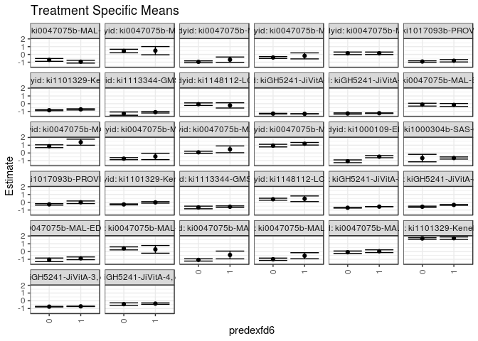

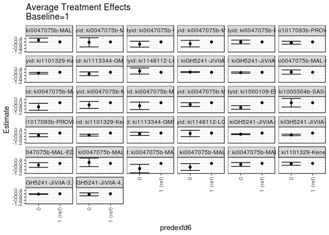

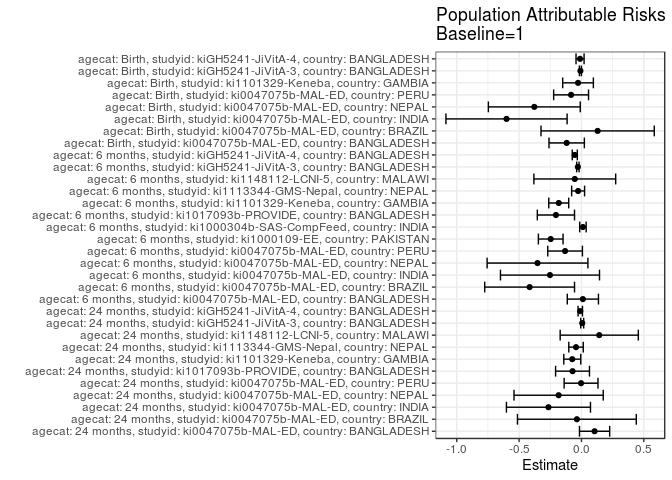

## Results Table

### Parameter: TSM

| agecat | studyid | country | intervention_level | baseline_level | estimate | ci_lower | ci_upper |
| --- | --- | --- | --- | --- | --- | --- | --- |
| Birth | ki0047075b-MAL-ED | BANGLADESH | 1 | NA | -0.8740309 | -1.0508176 | -0.6972441 |
| Birth | ki0047075b-MAL-ED | BANGLADESH | 0 | NA | -1.0718357 | -1.3024028 | -0.8412686 |
| Birth | ki0047075b-MAL-ED | BRAZIL | 1 | NA | 0.2776148 | -0.2192850 | 0.7745145 |
| Birth | ki0047075b-MAL-ED | BRAZIL | 0 | NA | 0.4048280 | 0.2073514 | 0.6023047 |
| Birth | ki0047075b-MAL-ED | INDIA | 1 | NA | -0.4428375 | -0.9435916 | 0.0579166 |
| Birth | ki0047075b-MAL-ED | INDIA | 0 | NA | -1.0806074 | -1.2295304 | -0.9316843 |
| Birth | ki0047075b-MAL-ED | NEPAL | 1 | NA | -0.5445911 | -0.9353788 | -0.1538034 |
| Birth | ki0047075b-MAL-ED | NEPAL | 0 | NA | -0.9979191 | -1.1465120 | -0.8493262 |
| Birth | ki0047075b-MAL-ED | PERU | 1 | NA | 0.0400049 | -0.1379001 | 0.2179100 |
| Birth | ki0047075b-MAL-ED | PERU | 0 | NA | -0.0913227 | -0.2483726 | 0.0657272 |
| Birth | ki1101329-Keneba | GAMBIA | 1 | NA | 1.7179476 | 1.5622839 | 1.8736113 |
| Birth | ki1101329-Keneba | GAMBIA | 0 | NA | 1.6786396 | 1.5782328 | 1.7790465 |
| Birth | kiGH5241-JiVitA-3 | BANGLADESH | 1 | NA | -0.7151400 | -0.7364469 | -0.6938331 |
| Birth | kiGH5241-JiVitA-3 | BANGLADESH | 0 | NA | -0.7553658 | -0.7950711 | -0.7156605 |
| Birth | kiGH5241-JiVitA-4 | BANGLADESH | 1 | NA | -0.3625945 | -0.4547476 | -0.2704414 |
| Birth | kiGH5241-JiVitA-4 | BANGLADESH | 0 | NA | -0.4312233 | -0.5982161 | -0.2642304 |
| 6 months | ki0047075b-MAL-ED | BANGLADESH | 1 | NA | -0.1577957 | -0.3461571 | 0.0305658 |
| 6 months | ki0047075b-MAL-ED | BANGLADESH | 0 | NA | -0.1257768 | -0.3088100 | 0.0572565 |
| 6 months | ki0047075b-MAL-ED | BRAZIL | 1 | NA | 1.3873267 | 0.9971993 | 1.7774541 |
| 6 months | ki0047075b-MAL-ED | BRAZIL | 0 | NA | 0.8721093 | 0.6937687 | 1.0504500 |
| 6 months | ki0047075b-MAL-ED | INDIA | 1 | NA | -0.4505509 | -0.8576706 | -0.0434313 |
| 6 months | ki0047075b-MAL-ED | INDIA | 0 | NA | -0.7306938 | -0.8624048 | -0.5989827 |
| 6 months | ki0047075b-MAL-ED | NEPAL | 1 | NA | 0.4691306 | 0.0308025 | 0.9074587 |
| 6 months | ki0047075b-MAL-ED | NEPAL | 0 | NA | 0.0865906 | -0.0494500 | 0.2226312 |
| 6 months | ki0047075b-MAL-ED | PERU | 1 | NA | 1.1866255 | 1.0195192 | 1.3537317 |
| 6 months | ki0047075b-MAL-ED | PERU | 0 | NA | 0.9492723 | 0.7810021 | 1.1175426 |
| 6 months | ki1000109-EE | PAKISTAN | 1 | NA | -0.4748524 | -0.6141288 | -0.3355759 |
| 6 months | ki1000109-EE | PAKISTAN | 0 | NA | -1.0687058 | -1.2472061 | -0.8902056 |
| 6 months | ki1000304b-SAS-CompFeed | INDIA | 1 | NA | -0.6465859 | -0.7848454 | -0.5083265 |
| 6 months | ki1000304b-SAS-CompFeed | INDIA | 0 | NA | -0.6556227 | -1.1386877 | -0.1725576 |
| 6 months | ki1017093b-PROVIDE | BANGLADESH | 1 | NA | -0.0036348 | -0.1711137 | 0.1638441 |
| 6 months | ki1017093b-PROVIDE | BANGLADESH | 0 | NA | -0.2736257 | -0.3707353 | -0.1765161 |
| 6 months | ki1101329-Keneba | GAMBIA | 1 | NA | -0.0176054 | -0.1148858 | 0.0796750 |
| 6 months | ki1101329-Keneba | GAMBIA | 0 | NA | -0.2806529 | -0.3433295 | -0.2179763 |
| 6 months | ki1113344-GMS-Nepal | NEPAL | 1 | NA | -0.5747164 | -0.6774980 | -0.4719348 |
| 6 months | ki1113344-GMS-Nepal | NEPAL | 0 | NA | -0.6702478 | -0.8400525 | -0.5004431 |
| 6 months | ki1148112-LCNI-5 | MALAWI | 1 | NA | 0.4462604 | 0.0834345 | 0.8090863 |
| 6 months | ki1148112-LCNI-5 | MALAWI | 0 | NA | 0.3889193 | 0.2604349 | 0.5174038 |
| 6 months | kiGH5241-JiVitA-3 | BANGLADESH | 1 | NA | -0.5644589 | -0.5859635 | -0.5429543 |
| 6 months | kiGH5241-JiVitA-3 | BANGLADESH | 0 | NA | -0.7082259 | -0.7503108 | -0.6661411 |
| 6 months | kiGH5241-JiVitA-4 | BANGLADESH | 1 | NA | -0.3436433 | -0.3903022 | -0.2969844 |
| 6 months | kiGH5241-JiVitA-4 | BANGLADESH | 0 | NA | -0.5781714 | -0.6560467 | -0.5002961 |
| 24 months | ki0047075b-MAL-ED | BANGLADESH | 1 | NA | -0.9367444 | -1.1153082 | -0.7581805 |
| 24 months | ki0047075b-MAL-ED | BANGLADESH | 0 | NA | -0.7070930 | -0.8866292 | -0.5275568 |
| 24 months | ki0047075b-MAL-ED | BRAZIL | 1 | NA | 0.4833102 | -0.0431339 | 1.0097544 |
| 24 months | ki0047075b-MAL-ED | BRAZIL | 0 | NA | 0.4407781 | 0.2171738 | 0.6643823 |
| 24 months | ki0047075b-MAL-ED | INDIA | 1 | NA | -0.6745254 | -1.0152810 | -0.3337698 |
| 24 months | ki0047075b-MAL-ED | INDIA | 0 | NA | -0.9514913 | -1.0735885 | -0.8293940 |
| 24 months | ki0047075b-MAL-ED | NEPAL | 1 | NA | -0.1871663 | -0.5748989 | 0.2005662 |
| 24 months | ki0047075b-MAL-ED | NEPAL | 0 | NA | -0.3960876 | -0.5138921 | -0.2782830 |
| 24 months | ki0047075b-MAL-ED | PERU | 1 | NA | 0.1462422 | -0.0135376 | 0.3060219 |
| 24 months | ki0047075b-MAL-ED | PERU | 0 | NA | 0.1419208 | -0.0261431 | 0.3099847 |
| 24 months | ki1017093b-PROVIDE | BANGLADESH | 1 | NA | -0.8164314 | -0.9721843 | -0.6606785 |
| 24 months | ki1017093b-PROVIDE | BANGLADESH | 0 | NA | -0.9141054 | -1.0102736 | -0.8179372 |
| 24 months | ki1101329-Keneba | GAMBIA | 1 | NA | -0.7296284 | -0.8129124 | -0.6463443 |
| 24 months | ki1101329-Keneba | GAMBIA | 0 | NA | -0.8396914 | -0.9013308 | -0.7780519 |
| 24 months | ki1113344-GMS-Nepal | NEPAL | 1 | NA | -1.0934041 | -1.1936468 | -0.9931615 |
| 24 months | ki1113344-GMS-Nepal | NEPAL | 0 | NA | -1.2755940 | -1.4844743 | -1.0667136 |
| 24 months | ki1148112-LCNI-5 | MALAWI | 1 | NA | -0.2197660 | -0.5561774 | 0.1166455 |
| 24 months | ki1148112-LCNI-5 | MALAWI | 0 | NA | -0.0611236 | -0.2246836 | 0.1024365 |
| 24 months | kiGH5241-JiVitA-3 | BANGLADESH | 1 | NA | -1.3051819 | -1.3315611 | -1.2788026 |
| 24 months | kiGH5241-JiVitA-3 | BANGLADESH | 0 | NA | -1.2790768 | -1.3266348 | -1.2315189 |
| 24 months | kiGH5241-JiVitA-4 | BANGLADESH | 1 | NA | -1.2241944 | -1.2611522 | -1.1872366 |
| 24 months | kiGH5241-JiVitA-4 | BANGLADESH | 0 | NA | -1.2624941 | -1.3386167 | -1.1863716 |

### Parameter: E(Y)

| agecat | studyid | country | intervention_level | baseline_level | estimate | ci_lower | ci_upper |
| --- | --- | --- | --- | --- | --- | --- | --- |
| Birth | ki0047075b-MAL-ED | BANGLADESH | NA | NA | -0.9925114 | -1.1346572 | -0.8503656 |
| Birth | ki0047075b-MAL-ED | BRAZIL | NA | NA | 0.4073214 | 0.2229599 | 0.5916830 |
| Birth | ki0047075b-MAL-ED | INDIA | NA | NA | -1.0435829 | -1.1865715 | -0.9005943 |
| Birth | ki0047075b-MAL-ED | NEPAL | NA | NA | -0.9226061 | -1.0630064 | -0.7822058 |
| Birth | ki0047075b-MAL-ED | PERU | NA | NA | -0.0430924 | -0.1600210 | 0.0738362 |
| Birth | ki1101329-Keneba | GAMBIA | NA | NA | 1.6904416 | 1.6057966 | 1.7750867 |
| Birth | kiGH5241-JiVitA-3 | BANGLADESH | NA | NA | -0.7234060 | -0.7433920 | -0.7034200 |
| Birth | kiGH5241-JiVitA-4 | BANGLADESH | NA | NA | -0.3738863 | -0.4580087 | -0.2897638 |
| 6 months | ki0047075b-MAL-ED | BANGLADESH | NA | NA | -0.1464929 | -0.2779745 | -0.0150113 |
| 6 months | ki0047075b-MAL-ED | BRAZIL | NA | NA | 0.9717225 | 0.8073791 | 1.1360658 |
| 6 months | ki0047075b-MAL-ED | INDIA | NA | NA | -0.7028736 | -0.8283047 | -0.5774424 |
| 6 months | ki0047075b-MAL-ED | NEPAL | NA | NA | 0.1167518 | -0.0146454 | 0.2481490 |
| 6 months | ki0047075b-MAL-ED | PERU | NA | NA | 1.0554461 | 0.9322755 | 1.1786167 |
| 6 months | ki1000109-EE | PAKISTAN | NA | NA | -0.7212766 | -0.8346857 | -0.6078675 |
| 6 months | ki1000304b-SAS-CompFeed | INDIA | NA | NA | -0.6348861 | -0.7630511 | -0.5067211 |
| 6 months | ki1017093b-PROVIDE | BANGLADESH | NA | NA | -0.2083706 | -0.2927992 | -0.1239419 |
| 6 months | ki1101329-Keneba | GAMBIA | NA | NA | -0.1997850 | -0.2531586 | -0.1464114 |
| 6 months | ki1113344-GMS-Nepal | NEPAL | NA | NA | -0.6015049 | -0.6892785 | -0.5137313 |
| 6 months | ki1148112-LCNI-5 | MALAWI | NA | NA | 0.3927574 | 0.2737700 | 0.5117448 |
| 6 months | kiGH5241-JiVitA-3 | BANGLADESH | NA | NA | -0.5931801 | -0.6126929 | -0.5736674 |
| 6 months | kiGH5241-JiVitA-4 | BANGLADESH | NA | NA | -0.3971948 | -0.4378192 | -0.3565704 |
| 24 months | ki0047075b-MAL-ED | BANGLADESH | NA | NA | -0.8315789 | -0.9546058 | -0.7085521 |
| 24 months | ki0047075b-MAL-ED | BRAZIL | NA | NA | 0.4466272 | 0.2416144 | 0.6516401 |
| 24 months | ki0047075b-MAL-ED | INDIA | NA | NA | -0.9390848 | -1.0545919 | -0.8235777 |
| 24 months | ki0047075b-MAL-ED | NEPAL | NA | NA | -0.3703084 | -0.4835704 | -0.2570464 |
| 24 months | ki0047075b-MAL-ED | PERU | NA | NA | 0.1430051 | 0.0254144 | 0.2605957 |
| 24 months | ki1017093b-PROVIDE | BANGLADESH | NA | NA | -0.8879412 | -0.9708680 | -0.8050144 |
| 24 months | ki1101329-Keneba | GAMBIA | NA | NA | -0.8032329 | -0.8532842 | -0.7531817 |
| 24 months | ki1113344-GMS-Nepal | NEPAL | NA | NA | -1.1369520 | -1.2269975 | -1.0469065 |
| 24 months | ki1148112-LCNI-5 | MALAWI | NA | NA | -0.0771196 | -0.2204715 | 0.0662323 |
| 24 months | kiGH5241-JiVitA-3 | BANGLADESH | NA | NA | -1.2991319 | -1.3225545 | -1.2757094 |
| 24 months | kiGH5241-JiVitA-4 | BANGLADESH | NA | NA | -1.2337581 | -1.2679680 | -1.1995482 |

### Parameter: ATE

| agecat | studyid | country | intervention_level | baseline_level | estimate | ci_lower | ci_upper |
| --- | --- | --- | --- | --- | --- | --- | --- |
| Birth | ki0047075b-MAL-ED | BANGLADESH | 1 | 1 | 0.0000000 | 0.0000000 | 0.0000000 |
| Birth | ki0047075b-MAL-ED | BANGLADESH | 0 | 1 | -0.1978048 | -0.4895521 | 0.0939425 |
| Birth | ki0047075b-MAL-ED | BRAZIL | 1 | 1 | 0.0000000 | 0.0000000 | 0.0000000 |
| Birth | ki0047075b-MAL-ED | BRAZIL | 0 | 1 | 0.1272133 | -0.4043089 | 0.6587354 |
| Birth | ki0047075b-MAL-ED | INDIA | 1 | 1 | 0.0000000 | 0.0000000 | 0.0000000 |
| Birth | ki0047075b-MAL-ED | INDIA | 0 | 1 | -0.6377699 | -1.1616733 | -0.1138664 |
| Birth | ki0047075b-MAL-ED | NEPAL | 1 | 1 | 0.0000000 | 0.0000000 | 0.0000000 |
| Birth | ki0047075b-MAL-ED | NEPAL | 0 | 1 | -0.4533280 | -0.8728215 | -0.0338346 |
| Birth | ki0047075b-MAL-ED | PERU | 1 | 1 | 0.0000000 | 0.0000000 | 0.0000000 |
| Birth | ki0047075b-MAL-ED | PERU | 0 | 1 | -0.1313276 | -0.3699552 | 0.1072999 |
| Birth | ki1101329-Keneba | GAMBIA | 1 | 1 | 0.0000000 | 0.0000000 | 0.0000000 |
| Birth | ki1101329-Keneba | GAMBIA | 0 | 1 | -0.0393080 | -0.2246259 | 0.1460100 |
| Birth | kiGH5241-JiVitA-3 | BANGLADESH | 1 | 1 | 0.0000000 | 0.0000000 | 0.0000000 |
| Birth | kiGH5241-JiVitA-3 | BANGLADESH | 0 | 1 | -0.0402258 | -0.0811390 | 0.0006873 |
| Birth | kiGH5241-JiVitA-4 | BANGLADESH | 1 | 1 | 0.0000000 | 0.0000000 | 0.0000000 |
| Birth | kiGH5241-JiVitA-4 | BANGLADESH | 0 | 1 | -0.0686288 | -0.2505342 | 0.1132767 |
| 6 months | ki0047075b-MAL-ED | BANGLADESH | 1 | 1 | 0.0000000 | 0.0000000 | 0.0000000 |
| 6 months | ki0047075b-MAL-ED | BANGLADESH | 0 | 1 | 0.0320189 | -0.2296862 | 0.2937240 |
| 6 months | ki0047075b-MAL-ED | BRAZIL | 1 | 1 | 0.0000000 | 0.0000000 | 0.0000000 |
| 6 months | ki0047075b-MAL-ED | BRAZIL | 0 | 1 | -0.5152174 | -0.9449025 | -0.0855322 |
| 6 months | ki0047075b-MAL-ED | INDIA | 1 | 1 | 0.0000000 | 0.0000000 | 0.0000000 |
| 6 months | ki0047075b-MAL-ED | INDIA | 0 | 1 | -0.2801428 | -0.7081937 | 0.1479080 |
| 6 months | ki0047075b-MAL-ED | NEPAL | 1 | 1 | 0.0000000 | 0.0000000 | 0.0000000 |
| 6 months | ki0047075b-MAL-ED | NEPAL | 0 | 1 | -0.3825400 | -0.8419631 | 0.0768831 |
| 6 months | ki0047075b-MAL-ED | PERU | 1 | 1 | 0.0000000 | 0.0000000 | 0.0000000 |
| 6 months | ki0047075b-MAL-ED | PERU | 0 | 1 | -0.2373531 | -0.4738672 | -0.0008390 |
| 6 months | ki1000109-EE | PAKISTAN | 1 | 1 | 0.0000000 | 0.0000000 | 0.0000000 |
| 6 months | ki1000109-EE | PAKISTAN | 0 | 1 | -0.5938535 | -0.8204418 | -0.3672651 |
| 6 months | ki1000304b-SAS-CompFeed | INDIA | 1 | 1 | 0.0000000 | 0.0000000 | 0.0000000 |
| 6 months | ki1000304b-SAS-CompFeed | INDIA | 0 | 1 | -0.0090367 | -0.5362411 | 0.5181676 |
| 6 months | ki1017093b-PROVIDE | BANGLADESH | 1 | 1 | 0.0000000 | 0.0000000 | 0.0000000 |
| 6 months | ki1017093b-PROVIDE | BANGLADESH | 0 | 1 | -0.2699910 | -0.4638239 | -0.0761580 |
| 6 months | ki1101329-Keneba | GAMBIA | 1 | 1 | 0.0000000 | 0.0000000 | 0.0000000 |
| 6 months | ki1101329-Keneba | GAMBIA | 0 | 1 | -0.2630475 | -0.3778397 | -0.1482552 |
| 6 months | ki1113344-GMS-Nepal | NEPAL | 1 | 1 | 0.0000000 | 0.0000000 | 0.0000000 |
| 6 months | ki1113344-GMS-Nepal | NEPAL | 0 | 1 | -0.0955314 | -0.2941479 | 0.1030851 |
| 6 months | ki1148112-LCNI-5 | MALAWI | 1 | 1 | 0.0000000 | 0.0000000 | 0.0000000 |
| 6 months | ki1148112-LCNI-5 | MALAWI | 0 | 1 | -0.0573410 | -0.4463008 | 0.3316187 |
| 6 months | kiGH5241-JiVitA-3 | BANGLADESH | 1 | 1 | 0.0000000 | 0.0000000 | 0.0000000 |
| 6 months | kiGH5241-JiVitA-3 | BANGLADESH | 0 | 1 | -0.1437671 | -0.1894077 | -0.0981264 |
| 6 months | kiGH5241-JiVitA-4 | BANGLADESH | 1 | 1 | 0.0000000 | 0.0000000 | 0.0000000 |
| 6 months | kiGH5241-JiVitA-4 | BANGLADESH | 0 | 1 | -0.2345281 | -0.3238411 | -0.1452151 |
| 24 months | ki0047075b-MAL-ED | BANGLADESH | 1 | 1 | 0.0000000 | 0.0000000 | 0.0000000 |
| 24 months | ki0047075b-MAL-ED | BANGLADESH | 0 | 1 | 0.2296514 | -0.0248263 | 0.4841291 |
| 24 months | ki0047075b-MAL-ED | BRAZIL | 1 | 1 | 0.0000000 | 0.0000000 | 0.0000000 |
| 24 months | ki0047075b-MAL-ED | BRAZIL | 0 | 1 | -0.0425322 | -0.6129756 | 0.5279113 |
| 24 months | ki0047075b-MAL-ED | INDIA | 1 | 1 | 0.0000000 | 0.0000000 | 0.0000000 |
| 24 months | ki0047075b-MAL-ED | INDIA | 0 | 1 | -0.2769659 | -0.6392971 | 0.0853653 |
| 24 months | ki0047075b-MAL-ED | NEPAL | 1 | 1 | 0.0000000 | 0.0000000 | 0.0000000 |
| 24 months | ki0047075b-MAL-ED | NEPAL | 0 | 1 | -0.2089212 | -0.6141839 | 0.1963415 |
| 24 months | ki0047075b-MAL-ED | PERU | 1 | 1 | 0.0000000 | 0.0000000 | 0.0000000 |
| 24 months | ki0047075b-MAL-ED | PERU | 0 | 1 | -0.0043214 | -0.2371108 | 0.2284681 |
| 24 months | ki1017093b-PROVIDE | BANGLADESH | 1 | 1 | 0.0000000 | 0.0000000 | 0.0000000 |
| 24 months | ki1017093b-PROVIDE | BANGLADESH | 0 | 1 | -0.0976740 | -0.2775185 | 0.0821704 |
| 24 months | ki1101329-Keneba | GAMBIA | 1 | 1 | 0.0000000 | 0.0000000 | 0.0000000 |
| 24 months | ki1101329-Keneba | GAMBIA | 0 | 1 | -0.1100630 | -0.2125772 | -0.0075488 |
| 24 months | ki1113344-GMS-Nepal | NEPAL | 1 | 1 | 0.0000000 | 0.0000000 | 0.0000000 |
| 24 months | ki1113344-GMS-Nepal | NEPAL | 0 | 1 | -0.1821898 | -0.4152527 | 0.0508731 |
| 24 months | ki1148112-LCNI-5 | MALAWI | 1 | 1 | 0.0000000 | 0.0000000 | 0.0000000 |
| 24 months | ki1148112-LCNI-5 | MALAWI | 0 | 1 | 0.1586424 | -0.2197946 | 0.5370794 |
| 24 months | kiGH5241-JiVitA-3 | BANGLADESH | 1 | 1 | 0.0000000 | 0.0000000 | 0.0000000 |
| 24 months | kiGH5241-JiVitA-3 | BANGLADESH | 0 | 1 | 0.0261050 | -0.0273768 | 0.0795868 |
| 24 months | kiGH5241-JiVitA-4 | BANGLADESH | 1 | 1 | 0.0000000 | 0.0000000 | 0.0000000 |
| 24 months | kiGH5241-JiVitA-4 | BANGLADESH | 0 | 1 | -0.0382998 | -0.1204904 | 0.0438909 |

### Parameter: PAR

| agecat | studyid | country | intervention_level | baseline_level | estimate | ci_lower | ci_upper |
| --- | --- | --- | --- | --- | --- | --- | --- |
| Birth | ki0047075b-MAL-ED | BANGLADESH | 1 | NA | -0.1184806 | -0.2602453 | 0.0232842 |
| Birth | ki0047075b-MAL-ED | BRAZIL | 1 | NA | 0.1297067 | -0.3244122 | 0.5838255 |
| Birth | ki0047075b-MAL-ED | INDIA | 1 | NA | -0.6007454 | -1.0863825 | -0.1151083 |
| Birth | ki0047075b-MAL-ED | NEPAL | 1 | NA | -0.3780150 | -0.7463515 | -0.0096785 |
| Birth | ki0047075b-MAL-ED | PERU | 1 | NA | -0.0830973 | -0.2229780 | 0.0567834 |
| Birth | ki1101329-Keneba | GAMBIA | 1 | NA | -0.0275060 | -0.1504482 | 0.0954362 |
| Birth | kiGH5241-JiVitA-3 | BANGLADESH | 1 | NA | -0.0082660 | -0.0163888 | -0.0001431 |
| Birth | kiGH5241-JiVitA-4 | BANGLADESH | 1 | NA | -0.0112918 | -0.0435994 | 0.0210158 |
| 6 months | ki0047075b-MAL-ED | BANGLADESH | 1 | NA | 0.0113028 | -0.1136466 | 0.1362521 |
| 6 months | ki0047075b-MAL-ED | BRAZIL | 1 | NA | -0.4156042 | -0.7755413 | -0.0556672 |
| 6 months | ki0047075b-MAL-ED | INDIA | 1 | NA | -0.2523226 | -0.6493225 | 0.1446773 |
| 6 months | ki0047075b-MAL-ED | NEPAL | 1 | NA | -0.3523788 | -0.7564007 | 0.0516430 |
| 6 months | ki0047075b-MAL-ED | PERU | 1 | NA | -0.1311794 | -0.2701432 | 0.0077844 |
| 6 months | ki1000109-EE | PAKISTAN | 1 | NA | -0.2464242 | -0.3453869 | -0.1474615 |
| 6 months | ki1000304b-SAS-CompFeed | INDIA | 1 | NA | 0.0116999 | -0.0141795 | 0.0375792 |
| 6 months | ki1017093b-PROVIDE | BANGLADESH | 1 | NA | -0.2047358 | -0.3538424 | -0.0556292 |
| 6 months | ki1101329-Keneba | GAMBIA | 1 | NA | -0.1821796 | -0.2621927 | -0.1021664 |
| 6 months | ki1113344-GMS-Nepal | NEPAL | 1 | NA | -0.0267885 | -0.0785995 | 0.0250225 |
| 6 months | ki1148112-LCNI-5 | MALAWI | 1 | NA | -0.0535030 | -0.3814201 | 0.2744141 |
| 6 months | kiGH5241-JiVitA-3 | BANGLADESH | 1 | NA | -0.0287212 | -0.0383261 | -0.0191164 |
| 6 months | kiGH5241-JiVitA-4 | BANGLADESH | 1 | NA | -0.0535515 | -0.0739044 | -0.0331986 |
| 24 months | ki0047075b-MAL-ED | BANGLADESH | 1 | NA | 0.1051654 | -0.0158799 | 0.2262107 |
| 24 months | ki0047075b-MAL-ED | BRAZIL | 1 | NA | -0.0366830 | -0.5130922 | 0.4397262 |
| 24 months | ki0047075b-MAL-ED | INDIA | 1 | NA | -0.2645594 | -0.6015449 | 0.0724260 |
| 24 months | ki0047075b-MAL-ED | NEPAL | 1 | NA | -0.1831420 | -0.5408281 | 0.1745440 |
| 24 months | ki0047075b-MAL-ED | PERU | 1 | NA | -0.0032371 | -0.1388577 | 0.1323835 |
| 24 months | ki1017093b-PROVIDE | BANGLADESH | 1 | NA | -0.0715098 | -0.2073183 | 0.0642986 |
| 24 months | ki1101329-Keneba | GAMBIA | 1 | NA | -0.0736046 | -0.1416887 | -0.0055204 |
| 24 months | ki1113344-GMS-Nepal | NEPAL | 1 | NA | -0.0435479 | -0.1014943 | 0.0143986 |
| 24 months | ki1148112-LCNI-5 | MALAWI | 1 | NA | 0.1426464 | -0.1706283 | 0.4559211 |
| 24 months | kiGH5241-JiVitA-3 | BANGLADESH | 1 | NA | 0.0060500 | -0.0056982 | 0.0177981 |
| 24 months | kiGH5241-JiVitA-4 | BANGLADESH | 1 | NA | -0.0095637 | -0.0273475 | 0.0082200 |